# dsci_II_project

# resamples

```r
set.seed(67)

resamp <- resamples(list(enet = enet_fit, ols = ols_fit, lasso = lasso_fit, ridge = ridge_fit, gam = gam_fit, mars = mars_fit))

summary(resamp)
```

```
##
## Call:
## summary.resamples(object = resamp)
##
## Models: enet, ols, lasso, ridge, gam, mars
## Number of resamples: 10
##
## MAE
##            Min.   1st Qu.    Median      Mean   3rd Qu.      Max. NA's
## enet  0.5382907 0.5540677 0.5673095 0.5651641 0.5754018 0.5850183    0
## ols   0.5337281 0.5530479 0.5685322 0.5657648 0.5746613 0.5938914    0
## lasso 0.5382907 0.5540677 0.5673095 0.5651641 0.5754018 0.5850183    0
## ridge 0.5385195 0.5544932 0.5677313 0.5655752 0.5756389 0.5858850    0
## gam   0.5402857 0.5560489 0.5643286 0.5648538 0.5733396 0.5906677    0
## mars  0.5419318 0.5617246 0.5668176 0.5680467 0.5754304 0.5966667    0
##
## RMSE
##            Min.   1st Qu.    Median      Mean   3rd Qu.      Max. NA's
## enet  0.6777963 0.6867489 0.7038638 0.7069183 0.7278563 0.7396059    0
## ols   0.6772553 0.6902241 0.7049909 0.7095562 0.7316584 0.7465207    0
## lasso 0.6777963 0.6867489 0.7038638 0.7069183 0.7278563 0.7396059    0
## ridge 0.6790934 0.6880983 0.7073573 0.7087951 0.7295680 0.7422544    0
## gam   0.6748032 0.6884442 0.7006600 0.7064651 0.7285618 0.7444308    0
## mars  0.6799642 0.6914314 0.7012848 0.7092797 0.7292769 0.7458848    0
##
## Rsquared
##            Min.   1st Qu.    Median      Mean   3rd Qu.      Max. NA's
## enet  0.1352050 0.1796566 0.1979205 0.1991726 0.2161934 0.2560116    0
## ols   0.1317340 0.1729421 0.1931844 0.1934841 0.2090219 0.2566592    0
## lasso 0.1352050 0.1796566 0.1979205 0.1991726 0.2161934 0.2560116    0
## ridge 0.1301077 0.1798126 0.1966833 0.1947715 0.2039399 0.2551335    0
## gam   0.1421973 0.1726076 0.2074321 0.2010715 0.2224894 0.2508943    0
## mars  0.1335032 0.1602571 0.1985899 0.1960338 0.2347478 0.2478336    0
```

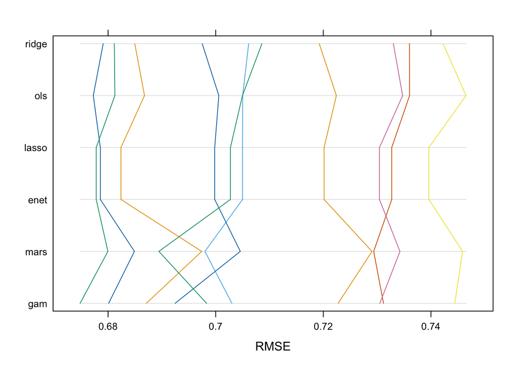

```r
parallelplot(resamp, metric = "RMSE")
```

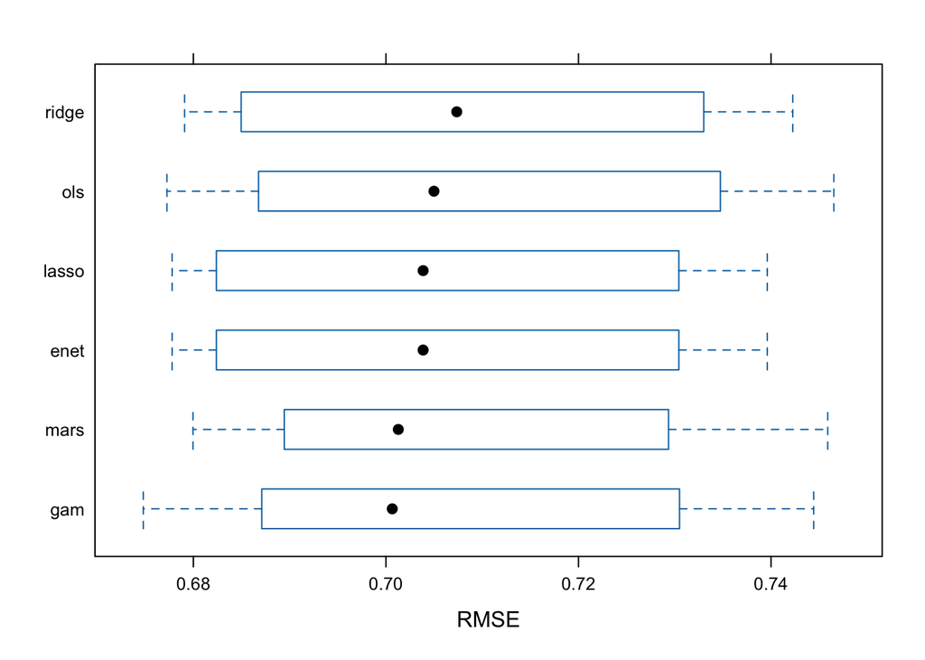

```r
bwplot(resamp, metric = "RMSE")
```

```r
cv_table <- summary(resamp)$statistics$RMSE |>
  as.data.frame() |>
  rownames_to_column(var = "Model") |>
  select(Model, Mean, Min., Max.) |>
  arrange(Mean) |>
  mutate(Model = Model,
         Mean = round(Mean, 4),
         Min. = round(Min., 4),
         Max. = round(Max., 4))

kable(cv_table,
      col.names = c("Model", "Mean RMSE", "Min RMSE", "Max RMSE"),
      caption = "Table 2. 10-fold cross-validation RMSE for models fitted on Dataset A")
```

Table 2. 10-fold cross-validation RMSE for models fitted on Dataset A

| Model | Mean RMSE | Min RMSE | Max RMSE |
| --- | --- | --- | --- |
| gam | 0.7065 | 0.6748 | 0.7444 |
| enet | 0.7069 | 0.6778 | 0.7396 |
| lasso | 0.7069 | 0.6778 | 0.7396 |
| ridge | 0.7088 | 0.6791 | 0.7423 |
| mars | 0.7093 | 0.6800 | 0.7459 |
| ols | 0.7096 | 0.6773 | 0.7465 |

no model is significantly better than any other,the differences in RMSE are not statistically significant. We will decide to go with LASSO over enet, since it only has 1 tuning parameter, no outliers and identical RMSE to enet.

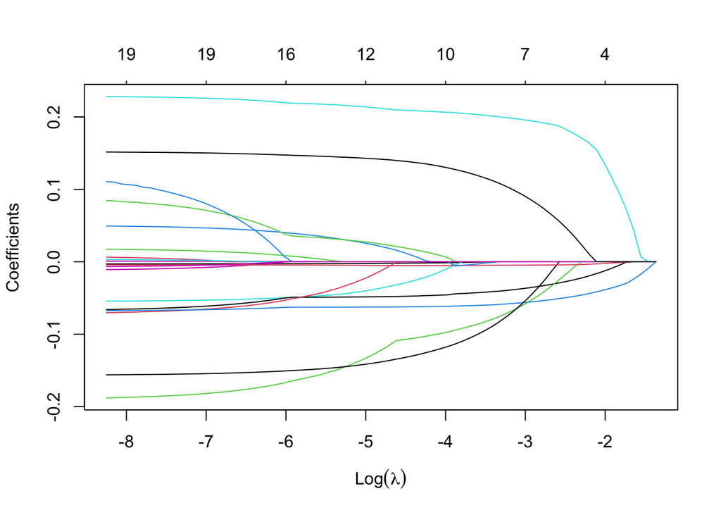

```r
plot(lasso_fit$finalModel)
```

# prediction

```r
lasso_pred <- predict(lasso_fit, newdata = testing_data)

# test RMSE
sqrt(mean((lasso_pred - testing_data$log_PFS)^2))
```

```
## [1] 0.6841792
```

```r
#R^2
cor(lasso_pred, testing_data$log_PFS)^2
```

```
## [1] 0.1900497
```

test RMSE = 0.68, slightly lower than CV RMSE = 0.706.

# Part II

```r
load("datB.RData")

datB <- datB |>
  select(-id) |>
  mutate(
    menopause = as.factor(menopause), # 0 = Pre-menopausal, 1 = Post-menopausal
    race = as.factor(race), # 1 = White, 2 = Black, 3 = Asian, 4 = Hispanic
    tumor_grade = as.factor(tumor_grade), # 1 = Well differentiated, 2 = Moderately differentiated, 3 = Poorly differentiated
    ER = as.factor(ER), # 0 = Negative, 1 = Positive
    PR = as.factor(PR), # 0 = Negative, 1 = Positive
    HER2 = as.factor(HER2), # 0 = Negative, 1 = Positive
    stage = as.factor(stage), # 1 = Stage I, 2 = Stage II, 3 = Stage III
    surgery = as.factor(surgery), # 0 = Breast-conserving surgery, 1 = Mastectomy
    chemo = as.factor(chemo), # 0 = No, 1 = Yes
    hormonal_therapy = as.factor(hormonal_therapy) # 0 = No, 1 = Yes
  )
```

# Comparison of datA and datB

```r
# labeled version for Table 1 only
datB_labeled <- datB |>
  mutate(
    menopause = factor(menopause, levels = c(0,1),
                       labels = c("Pre-menopausal", "Post-menopausal")),
    race = factor(race, levels = c(1,2,3,4),
                  labels = c("White", "Black", "Asian", "Hispanic")),
    tumor_grade = factor(tumor_grade, levels = c(1,2,3),
                         labels = c("Well differentiated",
                                    "Moderately differentiated",
                                    "Poorly differentiated")),
    ER = factor(ER, levels = c(0,1), labels = c("Negative", "Positive")),
    PR = factor(PR, levels = c(0,1), labels = c("Negative", "Positive")),
    HER2 = factor(HER2, levels = c(0,1), labels = c("Negative", "Positive")),
    stage = factor(stage, levels = c(1,2,3),
                   labels = c("Stage I", "Stage II", "Stage III")),
    surgery = factor(surgery, levels = c(0,1),
                     labels = c("Breast-conserving", "Mastectomy")),
    chemo = factor(chemo, levels = c(0,1), labels = c("No", "Yes")),
    hormonal_therapy = factor(hormonal_therapy, levels = c(0,1),
                              labels = c("No", "Yes"))
  )

table_b <- datB_labeled |>
  select(-log_PFS) |>
  tbl_summary(
    label = list(
      age              ~ "Age at diagnosis (years)",
      bmi              ~ "BMI (kg/m^2)",
      tumor_size       ~ "Tumor size (cm)",
      lymph_nodes      ~ "Positive lymph nodes (n)",
      Ki67             ~ "Ki-67 index (%)",
      menopause        ~ "Menopausal status",
      race             ~ "Race/ethnicity",
      tumor_grade      ~ "Tumor grade",
      ER               ~ "Estrogen receptor status",
      PR               ~ "Progesterone receptor status",
      HER2             ~ "HER2 status",
      stage            ~ "Clinical stage",
      surgery          ~ "Surgery type",
      chemo            ~ "Chemotherapy",
      hormonal_therapy ~ "Hormonal therapy"
    ),
    statistic = list(
      all_continuous()  ~ "{mean} ({sd})",
      all_categorical() ~ "{n} ({p}%)"
    ),
    digits = list(
      all_continuous()  ~ 1,
      all_categorical() ~ c(0, 1)
    )
  ) |>
  modify_header(label = "**Characteristic**") |>
  modify_caption("**Table 2. Baseline characteristics of datB (2000–2005 cohort, n=2000)**") |>
  bold_labels()

# merge side by side
tbl_merge(
  tbls = list(table_a, table_b),
  tab_spanner = c("**1990-1995 Cohort**", "**2000-2005 Cohort**")
) |>
  modify_caption("**Table 4. Baseline characteristics of Dataset A and Dataset B**")
```

**Table 4. Baseline characteristics of Dataset A and Dataset B**

| **Characteristic** | **1990-1995 Cohort** **N = 2,000**<sup>1</sup> | **2000-2005 Cohort** **N = 2,000**<sup>1</sup> |
| --- | --- | --- |
| Age at diagnosis (years) | 55.0 (11.7) | 56.1 (11.2) |
| Menopausal status |  |  |
| Pre-menopausal | 689 (34.5%) | 638 (31.9%) |
| Post-menopausal | 1,311 (65.6%) | 1,362 (68.1%) |
| Race/ethnicity |  |  |
| White | 1,284 (64.2%) | 1,097 (54.9%) |
| Black | 289 (14.5%) | 369 (18.5%) |
| Asian | 176 (8.8%) | 220 (11.0%) |
| Hispanic | 251 (12.6%) | 314 (15.7%) |
| BMI (kg/m^2) | 26.1 (4.6) | 27.4 (5.0) |
| Tumor size (cm) | 3.4 (1.7) | 3.1 (1.7) |
| Tumor grade |  |  |
| Well differentiated | 383 (19.2%) | 502 (25.1%) |
| Moderately differentiated | 871 (43.6%) | 839 (42.0%) |
| Poorly differentiated | 746 (37.3%) | 659 (33.0%) |
| Positive lymph nodes (n) | 2.6 (2.6) | 2.3 (2.5) |
| Estrogen receptor status |  |  |
| Negative | 719 (36.0%) | 652 (32.6%) |
| Positive | 1,281 (64.1%) | 1,348 (67.4%) |
| Progesterone receptor status |  |  |
| Negative | 1,039 (52.0%) | 991 (49.6%) |
| Positive | 961 (48.1%) | 1,009 (50.5%) |
| HER2 status |  |  |
| Negative | 1,556 (77.8%) | 1,526 (76.3%) |
| Positive | 444 (22.2%) | 474 (23.7%) |
| Ki-67 index (%) | 21.8 (11.6) | 20.4 (11.7) |
| Clinical stage |  |  |
| Stage I | 504 (25.2%) | 692 (34.6%) |
| Stage II | 893 (44.7%) | 828 (41.4%) |
| Stage III | 603 (30.2%) | 480 (24.0%) |
| Surgery type |  |  |
| Breast-conserving | 986 (49.3%) | 1,117 (55.9%) |
| Mastectomy | 1,014 (50.7%) | 883 (44.2%) |
| Chemotherapy | 1,105 (55.3%) | 1,298 (64.9%) |
| Hormonal therapy | 934 (46.7%) | 1,139 (57.0%) |

<sup>1</sup> Mean (SD); n (%)

# Predict with current LASSO

```r
# predict on datB
lasso_datB <- predict(lasso_fit, newdata = datB)

# RMSE on datB
sqrt(mean((lasso_datB - datB$log_PFS)^2))
```

```
## [1] 0.829317
```

```r
#R^2
cor(lasso_datB, datB$log_PFS)^2
```

```
## [1] 0.1565149
```

- RMSE increased substantially from 0.684 to 0.829, about a 21% increase in prediction error
- R^2 dropped from 0.190 to 0.157, explaining even less variance in the new cohort

```r
# Part II - datB analysis

# train/test split
set.seed(67)
data_splitB <- initial_split(datB, prop = 0.8)
training_dataB <- training(data_splitB)
testing_dataB <- testing(data_splitB)

# CV control
ctrl1 <- trainControl(method = "cv", number = 10, savePredictions = TRUE)

# OLS
set.seed(67)
ols_fitB <- train(log_PFS ~ ., data = training_dataB, method = "lm", trControl = ctrl1)

# Ridge
set.seed(67)
ridge_fitB <- train(log_PFS ~ ., data = training_dataB, method = "glmnet",
                    tuneGrid = expand.grid(alpha = 0, lambda = exp(seq(6, -4, length = 100))),
                    trControl = ctrl1)
# Lasso
set.seed(67)
lasso_fitB <- train(log_PFS ~ ., data = training_dataB, method = "glmnet",
                    tuneGrid = expand.grid(alpha = 1, lambda = exp(seq(4, -10, length = 100))),
                    trControl = ctrl1)
```

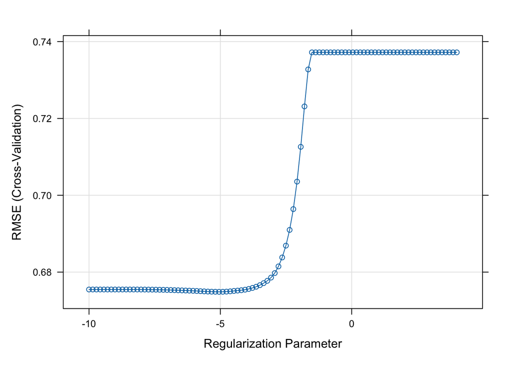

```r
plot(lasso_fitB, xTrans = log)
```

```r
# Elastic net
set.seed(67)
enet_fitB <- train(log_PFS ~ ., data = training_dataB, method = "glmnet",
                   tuneGrid = expand.grid(alpha = seq(0, 1, length = 21),
                                          lambda = exp(seq(4, -10, length = 100))),
                   trControl = ctrl1)
# GAM
set.seed(67)
gam_fitB <- train(log_PFS ~ ., data = training_dataB, method = "gam", trControl = ctrl1)

# MARS
set.seed(67)
mars_fitB <- train(log_PFS ~ ., data = training_dataB, method = "earth",
                   tuneGrid = mars_grid, trControl = ctrl1)

# Model comparison
resampB <- resamples(list(ols = ols_fitB, ridge = ridge_fitB, lasso = lasso_fitB,
                          enet = enet_fitB, gam = gam_fitB, mars = mars_fitB))
summary(resampB)
```

```
##
## Call:
## summary.resamples(object = resampB)
##
## Models: ols, ridge, lasso, enet, gam, mars
## Number of resamples: 10
##
## MAE
##            Min.   1st Qu.    Median      Mean   3rd Qu.      Max. NA's
## ols   0.5022711 0.5122949 0.5374245 0.5396088 0.5650435 0.5850137    0
## ridge 0.5032439 0.5128698 0.5367535 0.5382015 0.5591122 0.5764579    0
## lasso 0.5004316 0.5123126 0.5367669 0.5385622 0.5629375 0.5807758    0
## enet  0.5031558 0.5127948 0.5367685 0.5381869 0.5592506 0.5766371    0
## gam   0.5100143 0.5206053 0.5371817 0.5389959 0.5551839 0.5724727    0
## mars  0.5083307 0.5190839 0.5352303 0.5410699 0.5591859 0.5858931    0
##
## RMSE
##            Min.   1st Qu.    Median      Mean   3rd Qu.      Max. NA's
## ols   0.6346814 0.6477027 0.6723033 0.6756284 0.7066702 0.7226100    0
## ridge 0.6314345 0.6476131 0.6732795 0.6736970 0.7023192 0.7119490    0
## lasso 0.6323501 0.6458729 0.6737030 0.6748663 0.7047405 0.7179010    0
## enet  0.6314685 0.6475645 0.6732011 0.6736948 0.7024086 0.7121477    0
## gam   0.6340774 0.6513829 0.6715453 0.6730955 0.6965813 0.7075904    0
## mars  0.6366343 0.6458860 0.6728928 0.6741751 0.6973475 0.7201538    0
##
## Rsquared
##             Min.   1st Qu.    Median      Mean   3rd Qu.      Max. NA's
## ols   0.07067034 0.1514811 0.1684969 0.1663007 0.1903439 0.2704946    0
## ridge 0.07568797 0.1575395 0.1703577 0.1705426 0.1903816 0.2786331    0
## lasso 0.07191753 0.1494269 0.1675708 0.1672483 0.1917034 0.2699654    0
## enet  0.07557594 0.1574686 0.1703487 0.1704795 0.1904347 0.2784238    0
## gam   0.09732833 0.1512373 0.1727384 0.1699996 0.1928853 0.2638824    0
## mars  0.07553181 0.1446442 0.1598284 0.1681994 0.1973831 0.2784110    0
```

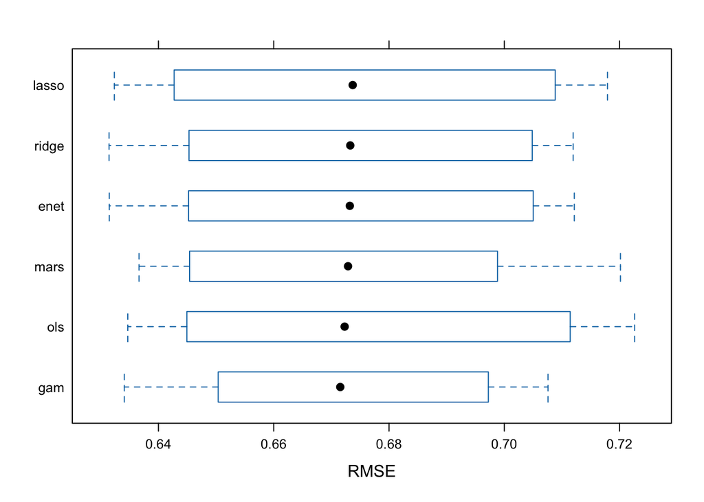

```r
bwplot(resampB, metric = "RMSE")
```

- CV RMSE range is 0.673-0.676, lower than datA 0.706-0.710

- GAM has the lowest mean RMSE (0.6731) again
- Ridge and enet are virtually identical (0.6737)
- All models very close again, we choose to compare LASSO models based on interpretability & consistency

```r
cv_tableB <- summary(resampB)$statistics$RMSE |>
  as.data.frame() |>
  rownames_to_column(var = "Model") |>
  select(Model, Mean, Min., Max.) |>
  arrange(Mean)

kable(cv_tableB, digits = 4,
      col.names = c("Model", "Mean RMSE", "Min RMSE", "Max RMSE"),
      caption = "Table 5. 10-fold CV RMSE for models fitted on Dataset B")
```

Table 5. 10-fold CV RMSE for models fitted on Dataset B

| Model | Mean RMSE | Min RMSE | Max RMSE |
| --- | --- | --- | --- |
| gam | 0.6731 | 0.6341 | 0.7076 |
| enet | 0.6737 | 0.6315 | 0.7121 |
| ridge | 0.6737 | 0.6314 | 0.7119 |
| mars | 0.6742 | 0.6366 | 0.7202 |
| lasso | 0.6749 | 0.6324 | 0.7179 |
| ols | 0.6756 | 0.6347 | 0.7226 |

# New LASSO prediction part II

```r
set.seed(67)
# predict on datB test set
lasso_predB <- predict(lasso_fitB, newdata = testing_dataB)

# test RMSE
sqrt(mean((lasso_predB - testing_dataB$log_PFS)^2))
```

```
## [1] 0.6673874
```

```r
# R^2
cor(lasso_predB, testing_dataB$log_PFS)^2
```

```
## [1] 0.184277
```

```r
coef(lasso_fitB$finalModel, s = lasso_fitB$bestTune$lambda)
```

```
## 20 x 1 sparse Matrix of class "dgCMatrix"
##                             s0
## (Intercept)        3.072693034
## age               -0.001056893
## menopause1        -0.030385590
## race2             -0.016998229
## race3              .
## race4              0.039220631
## bmi               -0.006005407
## tumor_size        -0.045470355
## tumor_grade2       0.079335320
## tumor_grade3      -0.113867622
## lymph_nodes       -0.029558059
## ER1                0.152841082
## PR1                0.032199936
## HER21              0.026412723
## Ki67              -0.003987201
## stage2             .
## stage3            -0.031408696
## surgery1          -0.035872647
## chemo1            -0.006697300
## hormonal_therapy1  0.202269382
```

# comparison table RMSE

```r
performance_table <- data.frame(
  Model = c("Lasso (Dataset A)",
            "Lasso (Dataset A) applied to Dataset B",
            "Lasso (Dataset B)"),
  CV_RMSE = c(0.7069, "-", 0.6749),
  Test_RMSE = c(0.6842, 0.8293, 0.6674),
  R2 = c(0.1900, 0.1565, 0.1843)
)

kable(performance_table,
      col.names = c("Model", "CV RMSE", "Test RMSE", "R²"),
      caption = "Table 6. Prediction performance summary",
      align = c("l", "c", "c", "c"),
      digits = 4)
```

Table 6. Prediction performance summary

| Model | CV RMSE | Test RMSE | R² |
| --- | --- | --- | --- |
| Lasso (Dataset A) | 0.7069 | 0.6842 | 0.1900 |
| Lasso (Dataset A) applied to Dataset B | - | 0.8293 | 0.1565 |
| Lasso (Dataset B) | 0.6749 | 0.6674 | 0.1843 |

# coefficient comparison

```r
# extract coefficients from both models
coef_A <- coef(lasso_fit$finalModel, s = lasso_fit$bestTune$lambda) |>
  as.matrix() |>
  as.data.frame()

coef_B <- coef(lasso_fitB$finalModel, s = lasso_fitB$bestTune$lambda) |>
  as.matrix() |>
  as.data.frame()

# combine into one table
coef_table <- cbind(coef_A, coef_B)
colnames(coef_table) <- c("datA (1990-95)", "datB (2000-05)")

coef_table
```

```
##                   datA (1990-95) datB (2000-05)
## (Intercept)          2.600416237    3.072693034
## age                 -0.001738541   -0.001056893
## menopause1           0.000000000   -0.030385590
## race2                0.000000000   -0.016998229
## race3                0.005695736    0.000000000
## race4               -0.024402590    0.039220631
## bmi                  0.000000000   -0.006005407
## tumor_size          -0.047114496   -0.045470355
## tumor_grade2         0.000000000    0.079335320
## tumor_grade3        -0.104548373   -0.113867622
## lymph_nodes         -0.062144518   -0.029558059
## ER1                  0.208395550    0.152841082
## PR1                  0.000000000    0.032199936
## HER21               -0.128160939    0.026412723
## Ki67                -0.005143791   -0.003987201
## stage2               0.015762828    0.000000000
## stage3               0.000000000   -0.031408696
## surgery1             0.000000000   -0.035872647
## chemo1               0.000000000   -0.006697300
## hormonal_therapy1    0.136572696    0.202269382
```

```r
kable(coef_table, digits = 3, caption = "Table 7. Lasso coefficients from datA and datB models")
```

Table 7. Lasso coefficients from datA and datB models

|  | datA (1990-95) | datB (2000-05) |
| --- | --- | --- |
| (Intercept) | 2.600 | 3.073 |
| age | -0.002 | -0.001 |
| menopause1 | 0.000 | -0.030 |
| race2 | 0.000 | -0.017 |
| race3 | 0.006 | 0.000 |
| race4 | -0.024 | 0.039 |
| bmi | 0.000 | -0.006 |
| tumor_size | -0.047 | -0.045 |
| tumor_grade2 | 0.000 | 0.079 |
| tumor_grade3 | -0.105 | -0.114 |
| lymph_nodes | -0.062 | -0.030 |
| ER1 | 0.208 | 0.153 |
| PR1 | 0.000 | 0.032 |
| HER21 | -0.128 | 0.026 |
| Ki67 | -0.005 | -0.004 |
| stage2 | 0.016 | 0.000 |
| stage3 | 0.000 | -0.031 |
| surgery1 | 0.000 | -0.036 |
| chemo1 | 0.000 | -0.007 |
| hormonal_therapy1 | 0.137 | 0.202 |

Changes - HER2 flipped from negative to positive. In the 1990s cohort HER2 positive was associated with worse PFS, but in the 2000s cohort it became slightly positive. HER2+ is no longer a poor prognostic factor.